# QC report: CSF proteome (PXD016278)

Runs excluded by the authors (13) are not shown; 197 runs and 1542 protein groups remain. 385 protein groups are quantified in every run.

## Run-level summary

Table 1: Run-level metrics by MS batch (mean across runs).

| batch | runs | sites | proteins quantified | % missing | median log2 (observed) | median log2 (complete) |
| --- | --- | --- | --- | --- | --- | --- |
| 20180618 | 60 | Sweden | 1137 | 26.3 | 16.91 | 19.27 |
| 20190210 | 54 | Magdeburg, Kiel | 1276 | 17.2 | 16.62 | 19.09 |
| 20190228 | 83 | Berlin | 1232 | 20.1 | 16.65 | 19.04 |

## Proteins quantified per run

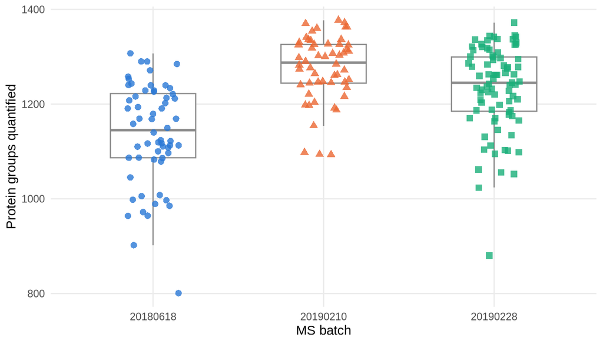

Figure 1: Protein groups quantified per run, by MS batch.

## Missing values bias the median of observed intensities

Spectronaut’s Local Normalization was applied across all runs. A per-run median computed on observed values alone is inflated in runs with more missing values, because missing values concentrate in low-abundance proteins.

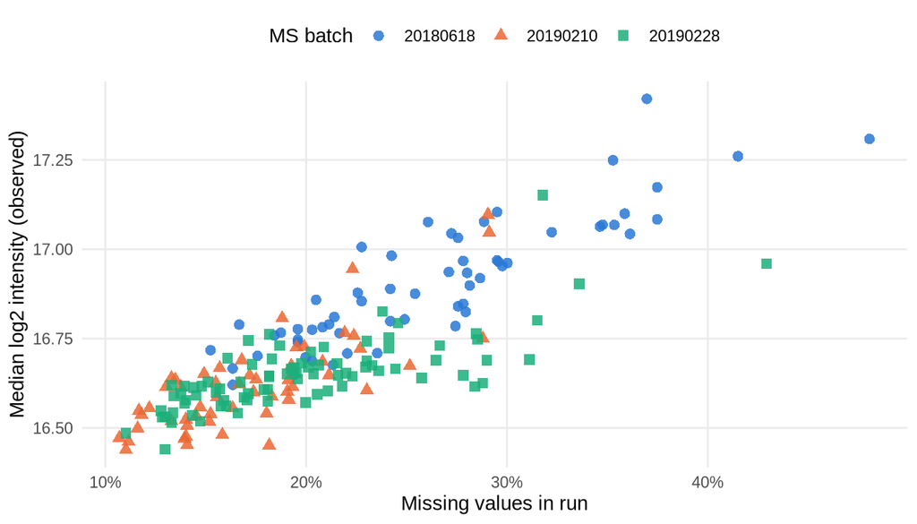

Figure 2: Per-run median log2 intensity of observed values against the fraction of missing values.

Correlation between missing fraction and median: 0.85 using observed values, -0.12 using only the 385 complete protein groups.

## Batch offset after removing the missingness effect

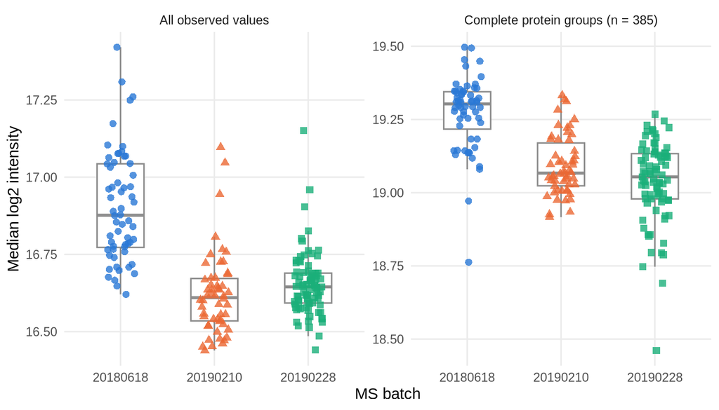

Figure 3: Per-run median log2 intensity by MS batch, on all observed values and on complete protein groups only.

## Normalization assessment

Per-run medians of complete protein groups were modelled on batch and diagnosis. Batch offsets are modelled as a covariate in limma rather than removed by renormalization, because run-level centering would also remove the small diagnosis-associated shift shown below.

Table 2: Linear model of per-run median log2 intensity (complete protein groups) on batch and diagnosis.

| term | estimate | ci_low | ci_high | p |
| --- | --- | --- | --- | --- |
| (Intercept) | 19.257 | 19.221 | 19.293 | 0.00 |
| batch20190210 | -0.180 | -0.226 | -0.134 | 0.00 |
| batch20190228 | -0.232 | -0.273 | -0.190 | 0.00 |
| groupAD | 0.032 | -0.003 | 0.068 | 0.07 |

## Drivers of missingness

Table 3: Linear model of the fraction of missing values per run on batch, age and diagnosis.

| term | estimate | ci_low | ci_high | p |
| --- | --- | --- | --- | --- |
| (Intercept) | 0.334 | 0.284 | 0.384 | 0.0e+00 |
| batch20190210 | -0.097 | -0.118 | -0.076 | 0.0e+00 |
| batch20190228 | -0.068 | -0.086 | -0.049 | 0.0e+00 |
| age | -0.001 | -0.001 | 0.000 | 3.4e-02 |
| groupAD | -0.035 | -0.051 | -0.019 | 3.9e-05 |

Missingness depends on diagnosis after adjusting for batch and age, so missing values are not independent of the contrast of interest. This rules out both left-censored imputation and analysis of observed values only, and motivates a model of the missingness mechanism in the differential abundance step.

## Runs with low protein coverage

Runs more than 3 median absolute deviations below their batch median in protein groups quantified. All are retained; sample-level quality weights are estimated in the limma model.

Table 4: Runs with low protein coverage relative to their MS batch.

| run | batch | site | group | age | n_quantified | % missing | median_complete |
| --- | --- | --- | --- | --- | --- | --- | --- |
| _CSF1_1_8-1xD1xS1fM1_sampleC09 | 20180618 | Sweden | control | 74 | 801 | 48.1 | 18.76 |
| SA_EASY12-10_Majken_E4_CSF_761 | 20190210 | Kiel | control | 24 | 1093 | 29.1 | 19.20 |
| SA_EASY12-10_Majken_E6_CSF_960 | 20190210 | Kiel | control | 20 | 1094 | 29.1 | 19.06 |
| SA_EASY12-10_Majken_E10_CSF_16 | 20190210 | Kiel | control | 47 | 1098 | 28.8 | 18.98 |
| desch_G9_82879903_190312181946 | 20190228 | Berlin | control | 56 | 880 | 42.9 | 18.46 |

## Blood contamination

Erythrocyte contamination is scored with a panel of erythrocyte-specific proteins (Geyer et al., 2019, *EMBO Mol Med*). Each protein is z-scored across runs, and the run score is the mean z-score of the panel proteins it contains.

Panel protein groups found: 9 (CA1, CA2, HBD, SLC4A1, CAT, BLVRB, PRDX2, HBB, HBA1).

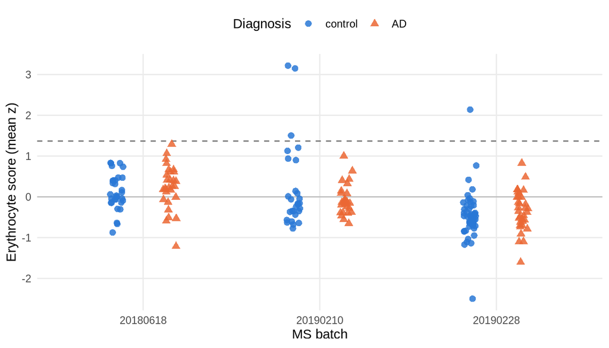

Figure 4: Erythrocyte contamination score per run, by MS batch and diagnosis. Dashed line: flagging threshold (median + 3 MAD).

Table 5: Linear model of the erythrocyte contamination score on batch and diagnosis.

| term | estimate | ci_low | ci_high | p |
| --- | --- | --- | --- | --- |
| (Intercept) | 0.171 | -0.008 | 0.350 | 6.0e-02 |
| batch20190210 | -0.111 | -0.339 | 0.118 | 3.4e-01 |
| batch20190228 | -0.592 | -0.799 | -0.385 | 1.0e-07 |
| groupAD | 0.013 | -0.163 | 0.188 | 8.9e-01 |

Contamination does not differ between diagnostic groups, so it is not expected to bias the AD vs. control comparison. 4 runs exceed the contamination threshold (median + 3 MAD = 1.37): all are retained in the main analysis and removed in a sensitivity analysis. Protein groups strongly correlated with the score are flagged as contamination-prone in the differential abundance results.

Table 6: Runs with the highest erythrocyte contamination score. Runs above the threshold are flagged.

| run | batch | site | group | ery_score | flagged |
| --- | --- | --- | --- | --- | --- |
| _SA_EASY12-10_Majken_E1_CSF_59 | 20190210 | Kiel | control | 3.22 | TRUE |
| A_EASY12-10_Majken_E12_CSF_146 | 20190210 | Kiel | control | 3.15 | TRUE |
| Y12-10_Deigendesch_E7_81758548 | 20190228 | Berlin | control | 2.14 | TRUE |
| A_EASY12-10_Majken_E11_CSF_783 | 20190210 | Kiel | control | 1.50 | TRUE |
| _CSF1_1_8-1xD1xS1fM1_sampleB09 | 20180618 | Sweden | AD | 1.29 | FALSE |
| SY12-10_Majken_C12_CSF_1299-14 | 20190210 | Magdeburg | control | 1.21 | FALSE |
| EASY12-10_Majken_B1_CSF_326-15 | 20190210 | Magdeburg | control | 1.13 | FALSE |
| _CSF1_1_8-1xD1xS1fM1_sampleE10 | 20180618 | Sweden | AD | 1.06 | FALSE |
| EASY12-10_Majken_B8_CSF_828-15 | 20190210 | Magdeburg | AD | 1.00 | FALSE |
| SA_EASY12-10_Majken_F3_CSF_865 | 20190210 | Kiel | control | 0.94 | FALSE |

## Principal component analysis

PCA on the 385 protein groups quantified in every run (no imputation), each scaled to unit variance.

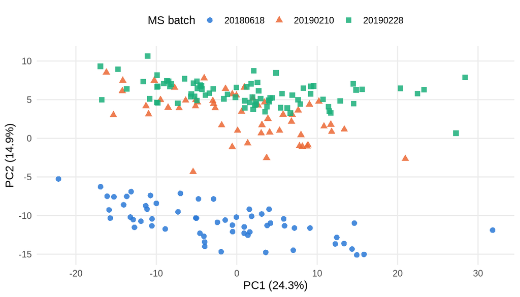

Figure 5: PC1 vs PC2, by MS batch.

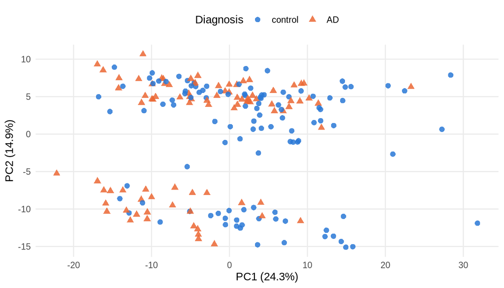

Figure 6: PC1 vs PC2, by diagnosis.

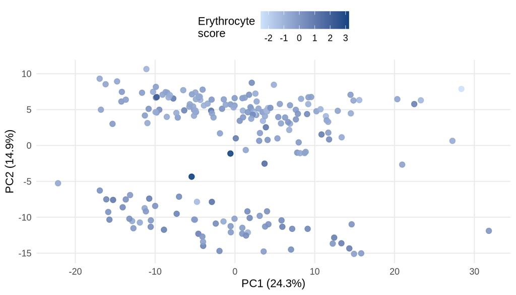

Figure 7: PC1 vs PC2, coloured by erythrocyte contamination score.

Table 7: Variance of each principal component explained by each covariate (R² of a linear model).

|  | batch | group | age | sex | ery_score | frac_missing |
| --- | --- | --- | --- | --- | --- | --- |
| PC1 (24.3%) | 0.02 | 0.11 | 0.03 | 0.06 | 0.02 | 0.41 |
| PC2 (14.9%) | 0.91 | 0.00 | 0.01 | 0.03 | 0.12 | 0.31 |
| PC3 (8.4%) | 0.58 | 0.00 | 0.14 | 0.00 | 0.04 | 0.01 |
| PC4 (4.6%) | 0.12 | 0.07 | 0.03 | 0.00 | 0.00 | 0.02 |
| PC5 (3.8%) | 0.11 | 0.02 | 0.15 | 0.08 | 0.03 | 0.03 |

### PC1: brain-derived vs plasma-derived proteins

Table 8: Protein groups with the largest PC1 loadings at each end.

| negative | positive |
| --- | --- |
| PTPRG | VTN |
| NELL2 | APOA1 |
| NRXN3 | C6 |
| PTPRF | SERPINA6 |
| PLD3 | AHSG |
| NRXN2 | HPX |
| NRCAM | PLG |
| RGMA | GC |
| IL6ST | SAA4 |
| CD99L2 | SERPINA1 |
| RGMB | ITIH4 |
| EPHA4 | F2 |
| NCAN | IGHG2 |
| GOT1 | SERPINA4 |
| SOD1 | TRBV7-2 |

One end of PC1 is formed by neuronal and neural extracellular-matrix proteins (neurexins, NRCAM, NCAN), the other by liver- and immune-derived plasma proteins (apolipoproteins, complement, protease inhibitors). PC1 therefore reflects the balance between brain-derived and plasma-derived protein in CSF, which depends largely on blood–CSF barrier permeability. PC1 is correlated with the overall intensity level of each run (r = -0.64) and partly associated with diagnosis.

A plasma-protein score is computed as for the erythrocyte score, from 13 protein groups of classic plasma proteins (SERPINA1, GC, HP, F2, PLG, APOA1, AHSG, ALB, TF, HPX). Its correlation with PC1 is 0.88; its correlation with the erythrocyte score is -0.11.

Table 9: Runs farthest from the centre of the PC1–PC2 plane (distance in units of each component’s SD).

| run | batch | group | age | PC1 | PC2 | plasma_score | ery_score | % missing |
| --- | --- | --- | --- | --- | --- | --- | --- | --- |
| _CSF1_1_8-1xD1xS1fM1_sampleC09 | 20180618 | control | 74 | 31.8 | -11.9 | 2.04 | 0.06 | 48.1 |
| desch_G9_82879903_190312181946 | 20190228 | control | 56 | 28.4 | 7.9 | 1.51 | -2.50 | 42.9 |
| 2-10_Deigendesch_A12_190103450 | 20190228 | control | 68 | 27.3 | 0.6 | 1.54 | -0.68 | 31.1 |
| _CSF1_1_8-1xD1xS1fM1_sampleD04 | 20180618 | control | 84 | 15.8 | -15.0 | 1.47 | -0.09 | 34.8 |
| Deigendesch_G1_82881418_repeat | 20190228 | AD | 71 | 23.3 | 6.3 | 1.47 | -1.10 | 28.8 |
| _CSF1_1_8-1xD1xS1fM1_sampleE02 | 20180618 | control | 67 | 14.9 | -15.1 | 0.78 | -0.30 | 37.5 |

The most distant runs lie at the plasma-rich end of PC1 and have normal erythrocyte scores: they reflect plasma protein entering CSF, not blood contamination at puncture. They are retained, since excluding them would bias the cohort towards individuals with an intact barrier. PC1 is not used as a covariate, because it carries part of the disease signal. The plasma score is used in a sensitivity analysis: candidate biomarkers that lose their association with diagnosis after adjusting for it are reported as possibly reflecting barrier permeability.